# Knee Misfit and the Geometry of the Aperiodic Component

Publication figure built from real specparam fits on simulated spectra

Author

Daniel Borek

This notebook generates a three-panel publication figure. Every curve is a **real `specparam` fit** to a **simulated** power spectrum — nothing is drawn analytically by hand.

- **Panel A — Misfit.** A spectrum with a genuine knee is fit with both the *knee* and the *fixed* aperiodic model. The fixed model has no plateau term, so it tilts a straight line through the data and **underestimates the exponent**. The exponent is routinely read as “the 1/f slope” — a biased exponent means a biased physiological interpretation.
- **Panel B — Knee parameter.** Low vs. high knee (`k`), exponent held fixed. `k` sets the plateau height and the knee frequency `f_k = k^(1/χ)`.
- **Panel C — Exponent.** Low vs. high exponent (`χ`), knee held fixed. `χ` sets the high-frequency slope; the low-frequency plateau is shared.

All text is exported as vector paths (`svg.fonttype='path'`), so the SVGs embed identically in slides and the thesis regardless of installed fonts.

## Panel A — Misfit: fixed mode flattens the exponent

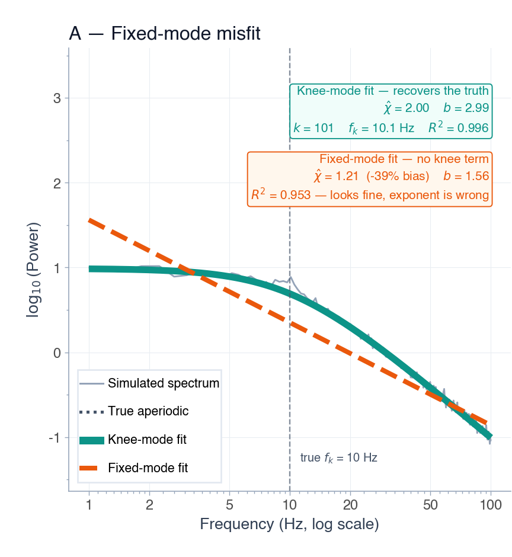

The fixed model reaches an R² that looks perfectly acceptable, yet its exponent is biased low by tens of percent: with no plateau term it pivots a straight line through plateau **and** slope. Reading that exponent as a “1/f / E:I” index would carry the bias straight into the physiological claim.

## Panel B — Knee parameter: plateau height and knee position

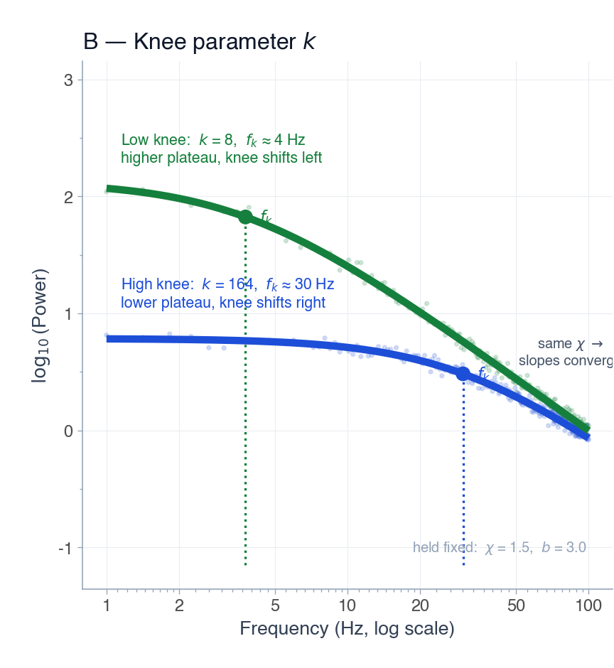

## Panel C — Exponent: high-frequency slope

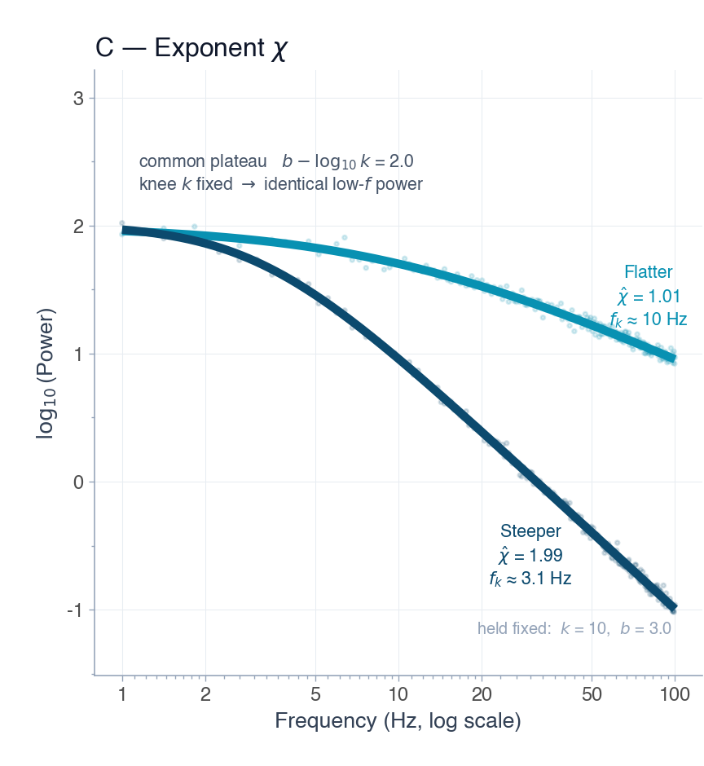

## Export

Each panel is saved standalone (for individual slides); the combined figure is assembled by nesting those standalone SVGs side by side, so every panel keeps the exact layout shown above.

|  | Model | offset b | exponent χ | knee k | f_k (Hz) |
| --- | --- | --- | --- | --- | --- |
| 0 | Panel A — true | 3.00 | 2.00 | 100 | 10.0 |
| 1 | Panel A — knee fit | 2.99 | 2.00 | 101 | 10.1 |
| 2 | Panel A — fixed fit | 1.56 | 1.21 | — | — |